# titanicsafe

## Minor project:TITANIC

## Name:saicharan shetty

## MLBATCH-2

```python
import numpy as np
import pandas as pd
import matplotlib.pyplot as plt
import seaborn as sns
%matplotlib inline
eda=pd.read_csv('TITANIC.CSV')
eda
#row=891*col=12
```

|  | PassengerId | Survived | Pclass | Name | Sex | Age | SibSp | Parch | Ticket | Fare | Cabin | Embarked |
| --- | --- | --- | --- | --- | --- | --- | --- | --- | --- | --- | --- | --- |
| 0 | 1 | 0 | 3 | Braund, Mr. Owen Harris | male | 22.0 | 1 | 0 | A/5 21171 | 7.2500 | NaN | S |
| 1 | 2 | 1 | 1 | Cumings, Mrs. John Bradley (Florence Briggs Th... | female | 38.0 | 1 | 0 | PC 17599 | 71.2833 | C85 | C |
| 2 | 3 | 1 | 3 | Heikkinen, Miss. Laina | female | 26.0 | 0 | 0 | STON/O2. 3101282 | 7.9250 | NaN | S |
| 3 | 4 | 1 | 1 | Futrelle, Mrs. Jacques Heath (Lily May Peel) | female | 35.0 | 1 | 0 | 113803 | 53.1000 | C123 | S |
| 4 | 5 | 0 | 3 | Allen, Mr. William Henry | male | 35.0 | 0 | 0 | 373450 | 8.0500 | NaN | S |
| 5 | 6 | 0 | 3 | Moran, Mr. James | male | NaN | 0 | 0 | 330877 | 8.4583 | NaN | Q |
| 6 | 7 | 0 | 1 | McCarthy, Mr. Timothy J | male | 54.0 | 0 | 0 | 17463 | 51.8625 | E46 | S |
| 7 | 8 | 0 | 3 | Palsson, Master. Gosta Leonard | male | 2.0 | 3 | 1 | 349909 | 21.0750 | NaN | S |
| 8 | 9 | 1 | 3 | Johnson, Mrs. Oscar W (Elisabeth Vilhelmina Berg) | female | 27.0 | 0 | 2 | 347742 | 11.1333 | NaN | S |
| 9 | 10 | 1 | 2 | Nasser, Mrs. Nicholas (Adele Achem) | female | 14.0 | 1 | 0 | 237736 | 30.0708 | NaN | C |
| 10 | 11 | 1 | 3 | Sandstrom, Miss. Marguerite Rut | female | 4.0 | 1 | 1 | PP 9549 | 16.7000 | G6 | S |
| 11 | 12 | 1 | 1 | Bonnell, Miss. Elizabeth | female | 58.0 | 0 | 0 | 113783 | 26.5500 | C103 | S |
| 12 | 13 | 0 | 3 | Saundercock, Mr. William Henry | male | 20.0 | 0 | 0 | A/5. 2151 | 8.0500 | NaN | S |
| 13 | 14 | 0 | 3 | Andersson, Mr. Anders Johan | male | 39.0 | 1 | 5 | 347082 | 31.2750 | NaN | S |
| 14 | 15 | 0 | 3 | Vestrom, Miss. Hulda Amanda Adolfina | female | 14.0 | 0 | 0 | 350406 | 7.8542 | NaN | S |
| 15 | 16 | 1 | 2 | Hewlett, Mrs. (Mary D Kingcome) | female | 55.0 | 0 | 0 | 248706 | 16.0000 | NaN | S |
| 16 | 17 | 0 | 3 | Rice, Master. Eugene | male | 2.0 | 4 | 1 | 382652 | 29.1250 | NaN | Q |
| 17 | 18 | 1 | 2 | Williams, Mr. Charles Eugene | male | NaN | 0 | 0 | 244373 | 13.0000 | NaN | S |
| 18 | 19 | 0 | 3 | Vander Planke, Mrs. Julius (Emelia Maria Vande... | female | 31.0 | 1 | 0 | 345763 | 18.0000 | NaN | S |
| 19 | 20 | 1 | 3 | Masselmani, Mrs. Fatima | female | NaN | 0 | 0 | 2649 | 7.2250 | NaN | C |
| 20 | 21 | 0 | 2 | Fynney, Mr. Joseph J | male | 35.0 | 0 | 0 | 239865 | 26.0000 | NaN | S |
| 21 | 22 | 1 | 2 | Beesley, Mr. Lawrence | male | 34.0 | 0 | 0 | 248698 | 13.0000 | D56 | S |
| 22 | 23 | 1 | 3 | McGowan, Miss. Anna "Annie" | female | 15.0 | 0 | 0 | 330923 | 8.0292 | NaN | Q |
| 23 | 24 | 1 | 1 | Sloper, Mr. William Thompson | male | 28.0 | 0 | 0 | 113788 | 35.5000 | A6 | S |
| 24 | 25 | 0 | 3 | Palsson, Miss. Torborg Danira | female | 8.0 | 3 | 1 | 349909 | 21.0750 | NaN | S |
| 25 | 26 | 1 | 3 | Asplund, Mrs. Carl Oscar (Selma Augusta Emilia... | female | 38.0 | 1 | 5 | 347077 | 31.3875 | NaN | S |
| 26 | 27 | 0 | 3 | Emir, Mr. Farred Chehab | male | NaN | 0 | 0 | 2631 | 7.2250 | NaN | C |
| 27 | 28 | 0 | 1 | Fortune, Mr. Charles Alexander | male | 19.0 | 3 | 2 | 19950 | 263.0000 | C23 C25 C27 | S |
| 28 | 29 | 1 | 3 | O'Dwyer, Miss. Ellen "Nellie" | female | NaN | 0 | 0 | 330959 | 7.8792 | NaN | Q |
| 29 | 30 | 0 | 3 | Todoroff, Mr. Lalio | male | NaN | 0 | 0 | 349216 | 7.8958 | NaN | S |
| ... | ... | ... | ... | ... | ... | ... | ... | ... | ... | ... | ... | ... |
| 861 | 862 | 0 | 2 | Giles, Mr. Frederick Edward | male | 21.0 | 1 | 0 | 28134 | 11.5000 | NaN | S |
| 862 | 863 | 1 | 1 | Swift, Mrs. Frederick Joel (Margaret Welles Ba... | female | 48.0 | 0 | 0 | 17466 | 25.9292 | D17 | S |
| 863 | 864 | 0 | 3 | Sage, Miss. Dorothy Edith "Dolly" | female | NaN | 8 | 2 | CA. 2343 | 69.5500 | NaN | S |
| 864 | 865 | 0 | 2 | Gill, Mr. John William | male | 24.0 | 0 | 0 | 233866 | 13.0000 | NaN | S |
| 865 | 866 | 1 | 2 | Bystrom, Mrs. (Karolina) | female | 42.0 | 0 | 0 | 236852 | 13.0000 | NaN | S |
| 866 | 867 | 1 | 2 | Duran y More, Miss. Asuncion | female | 27.0 | 1 | 0 | SC/PARIS 2149 | 13.8583 | NaN | C |
| 867 | 868 | 0 | 1 | Roebling, Mr. Washington Augustus II | male | 31.0 | 0 | 0 | PC 17590 | 50.4958 | A24 | S |
| 868 | 869 | 0 | 3 | van Melkebeke, Mr. Philemon | male | NaN | 0 | 0 | 345777 | 9.5000 | NaN | S |
| 869 | 870 | 1 | 3 | Johnson, Master. Harold Theodor | male | 4.0 | 1 | 1 | 347742 | 11.1333 | NaN | S |
| 870 | 871 | 0 | 3 | Balkic, Mr. Cerin | male | 26.0 | 0 | 0 | 349248 | 7.8958 | NaN | S |
| 871 | 872 | 1 | 1 | Beckwith, Mrs. Richard Leonard (Sallie Monypeny) | female | 47.0 | 1 | 1 | 11751 | 52.5542 | D35 | S |
| 872 | 873 | 0 | 1 | Carlsson, Mr. Frans Olof | male | 33.0 | 0 | 0 | 695 | 5.0000 | B51 B53 B55 | S |
| 873 | 874 | 0 | 3 | Vander Cruyssen, Mr. Victor | male | 47.0 | 0 | 0 | 345765 | 9.0000 | NaN | S |
| 874 | 875 | 1 | 2 | Abelson, Mrs. Samuel (Hannah Wizosky) | female | 28.0 | 1 | 0 | P/PP 3381 | 24.0000 | NaN | C |
| 875 | 876 | 1 | 3 | Najib, Miss. Adele Kiamie "Jane" | female | 15.0 | 0 | 0 | 2667 | 7.2250 | NaN | C |
| 876 | 877 | 0 | 3 | Gustafsson, Mr. Alfred Ossian | male | 20.0 | 0 | 0 | 7534 | 9.8458 | NaN | S |
| 877 | 878 | 0 | 3 | Petroff, Mr. Nedelio | male | 19.0 | 0 | 0 | 349212 | 7.8958 | NaN | S |
| 878 | 879 | 0 | 3 | Laleff, Mr. Kristo | male | NaN | 0 | 0 | 349217 | 7.8958 | NaN | S |
| 879 | 880 | 1 | 1 | Potter, Mrs. Thomas Jr (Lily Alexenia Wilson) | female | 56.0 | 0 | 1 | 11767 | 83.1583 | C50 | C |
| 880 | 881 | 1 | 2 | Shelley, Mrs. William (Imanita Parrish Hall) | female | 25.0 | 0 | 1 | 230433 | 26.0000 | NaN | S |
| 881 | 882 | 0 | 3 | Markun, Mr. Johann | male | 33.0 | 0 | 0 | 349257 | 7.8958 | NaN | S |
| 882 | 883 | 0 | 3 | Dahlberg, Miss. Gerda Ulrika | female | 22.0 | 0 | 0 | 7552 | 10.5167 | NaN | S |
| 883 | 884 | 0 | 2 | Banfield, Mr. Frederick James | male | 28.0 | 0 | 0 | C.A./SOTON 34068 | 10.5000 | NaN | S |
| 884 | 885 | 0 | 3 | Sutehall, Mr. Henry Jr | male | 25.0 | 0 | 0 | SOTON/OQ 392076 | 7.0500 | NaN | S |
| 885 | 886 | 0 | 3 | Rice, Mrs. William (Margaret Norton) | female | 39.0 | 0 | 5 | 382652 | 29.1250 | NaN | Q |
| 886 | 887 | 0 | 2 | Montvila, Rev. Juozas | male | 27.0 | 0 | 0 | 211536 | 13.0000 | NaN | S |
| 887 | 888 | 1 | 1 | Graham, Miss. Margaret Edith | female | 19.0 | 0 | 0 | 112053 | 30.0000 | B42 | S |
| 888 | 889 | 0 | 3 | Johnston, Miss. Catherine Helen "Carrie" | female | NaN | 1 | 2 | W./C. 6607 | 23.4500 | NaN | S |
| 889 | 890 | 1 | 1 | Behr, Mr. Karl Howell | male | 26.0 | 0 | 0 | 111369 | 30.0000 | C148 | C |
| 890 | 891 | 0 | 3 | Dooley, Mr. Patrick | male | 32.0 | 0 | 0 | 370376 | 7.7500 | NaN | Q |

891 rows × 12 columns

# step1:

```python
eda.head()
```

|  | PassengerId | Survived | Pclass | Name | Sex | Age | SibSp | Parch | Ticket | Fare | Cabin | Embarked |
| --- | --- | --- | --- | --- | --- | --- | --- | --- | --- | --- | --- | --- |
| 0 | 1 | 0 | 3 | Braund, Mr. Owen Harris | male | 22.0 | 1 | 0 | A/5 21171 | 7.2500 | NaN | S |
| 1 | 2 | 1 | 1 | Cumings, Mrs. John Bradley (Florence Briggs Th... | female | 38.0 | 1 | 0 | PC 17599 | 71.2833 | C85 | C |
| 2 | 3 | 1 | 3 | Heikkinen, Miss. Laina | female | 26.0 | 0 | 0 | STON/O2. 3101282 | 7.9250 | NaN | S |
| 3 | 4 | 1 | 1 | Futrelle, Mrs. Jacques Heath (Lily May Peel) | female | 35.0 | 1 | 0 | 113803 | 53.1000 | C123 | S |
| 4 | 5 | 0 | 3 | Allen, Mr. William Henry | male | 35.0 | 0 | 0 | 373450 | 8.0500 | NaN | S |

```python
eda.tail()
```

|  | PassengerId | Survived | Pclass | Name | Sex | Age | SibSp | Parch | Ticket | Fare | Cabin | Embarked |
| --- | --- | --- | --- | --- | --- | --- | --- | --- | --- | --- | --- | --- |
| 886 | 887 | 0 | 2 | Montvila, Rev. Juozas | male | 27.0 | 0 | 0 | 211536 | 13.00 | NaN | S |
| 887 | 888 | 1 | 1 | Graham, Miss. Margaret Edith | female | 19.0 | 0 | 0 | 112053 | 30.00 | B42 | S |
| 888 | 889 | 0 | 3 | Johnston, Miss. Catherine Helen "Carrie" | female | NaN | 1 | 2 | W./C. 6607 | 23.45 | NaN | S |
| 889 | 890 | 1 | 1 | Behr, Mr. Karl Howell | male | 26.0 | 0 | 0 | 111369 | 30.00 | C148 | C |
| 890 | 891 | 0 | 3 | Dooley, Mr. Patrick | male | 32.0 | 0 | 0 | 370376 | 7.75 | NaN | Q |

```python
eda.info()
```

```
<class 'pandas.core.frame.DataFrame'>
RangeIndex: 891 entries, 0 to 890
Data columns (total 12 columns):
PassengerId    891 non-null int64
Survived       891 non-null int64
Pclass         891 non-null int64
Name           891 non-null object
Sex            891 non-null object
Age            714 non-null float64
SibSp          891 non-null int64
Parch          891 non-null int64
Ticket         891 non-null object
Fare           891 non-null float64
Cabin          204 non-null object
Embarked       889 non-null object
dtypes: float64(2), int64(5), object(5)
memory usage: 83.6+ KB
```

### here column age,cabin,embarked has some null values

Dependent Variable:survived  
Independent Variables:pclass,cabin,sex,age,sibsp,parch,fare,embarked  
VARIABLE CATEGORY:  
CATEGORICAL:sex,embarked,,cabin  
CONTINUOUS:AGE,FARE  
DISCREETE:survived,sibsp,parch,pclass,

```python
eda.isnull().sum()
```

```
PassengerId      0
Survived         0
Pclass           0
Name             0
Sex              0
Age            177
SibSp            0
Parch            0
Ticket           0
Fare             0
Cabin          687
Embarked         2
dtype: int64
```

```python
eda.describe(include='all')
```

|  | PassengerId | Survived | Pclass | Name | Sex | Age | SibSp | Parch | Ticket | Fare | Cabin | Embarked |
| --- | --- | --- | --- | --- | --- | --- | --- | --- | --- | --- | --- | --- |
| count | 891.000000 | 891.000000 | 891.000000 | 891 | 891 | 714.000000 | 891.000000 | 891.000000 | 891 | 891.000000 | 204 | 889 |
| unique | NaN | NaN | NaN | 891 | 2 | NaN | NaN | NaN | 681 | NaN | 147 | 3 |
| top | NaN | NaN | NaN | Hampe, Mr. Leon | male | NaN | NaN | NaN | CA. 2343 | NaN | C23 C25 C27 | S |
| freq | NaN | NaN | NaN | 1 | 577 | NaN | NaN | NaN | 7 | NaN | 4 | 644 |
| mean | 446.000000 | 0.383838 | 2.308642 | NaN | NaN | 29.699118 | 0.523008 | 0.381594 | NaN | 32.204208 | NaN | NaN |
| std | 257.353842 | 0.486592 | 0.836071 | NaN | NaN | 14.526497 | 1.102743 | 0.806057 | NaN | 49.693429 | NaN | NaN |
| min | 1.000000 | 0.000000 | 1.000000 | NaN | NaN | 0.420000 | 0.000000 | 0.000000 | NaN | 0.000000 | NaN | NaN |
| 25% | 223.500000 | 0.000000 | 2.000000 | NaN | NaN | 20.125000 | 0.000000 | 0.000000 | NaN | 7.910400 | NaN | NaN |
| 50% | 446.000000 | 0.000000 | 3.000000 | NaN | NaN | 28.000000 | 0.000000 | 0.000000 | NaN | 14.454200 | NaN | NaN |
| 75% | 668.500000 | 1.000000 | 3.000000 | NaN | NaN | 38.000000 | 1.000000 | 0.000000 | NaN | 31.000000 | NaN | NaN |
| max | 891.000000 | 1.000000 | 3.000000 | NaN | NaN | 80.000000 | 8.000000 | 6.000000 | NaN | 512.329200 | NaN | NaN |

#### HERE age differs from 0.42 yrs-80yrs with mean age of 29.6yrs,fare max value 512 and mean fare prize of 32 indictaing there may be VIPS

# STEP2:

### Categ: Gender:

```python
#no.of people survived and not
eda['Survived'].value_counts()
```

```
0    549
1    342
Name: Survived, dtype: int64
```

```python
#no. of male and female
eda['Sex'].value_counts()
```

```
male      577
female    314
Name: Sex, dtype: int64
```

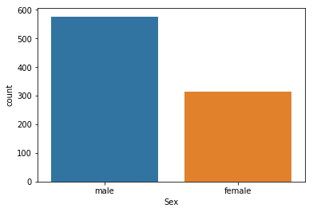

```python
sns.countplot('Sex',data=eda)
```

### CONTINUOUS:

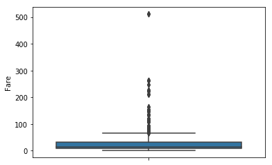

```python
sns.boxplot(y='Fare',data=eda)
```

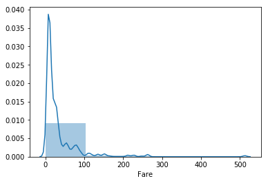

```python
sns.distplot(eda['Fare'],bins=5)
```

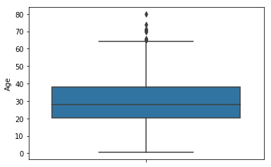

```python
sns.boxplot(y='Age',data=eda)
```

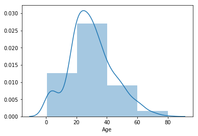

```python
sns.distplot(eda['Age'],bins=4)
```

# step3:

## Categorical:

### Gender:

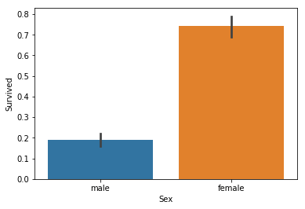

```python
sns.barplot(x='Sex',y='Survived',data=eda)
```

|  | female | male |
| --- | --- | --- |
| s | 233 | 109 |
| d | 81 | 468 |

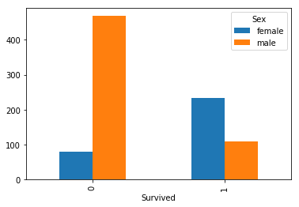

```python
pd.crosstab(eda['Survived'],eda['Sex']).plot(kind='bar')
s=eda[eda['Survived']==1]['Sex'].value_counts()
d=eda[eda['Survived']==0]['Sex'].value_counts()
pd.DataFrame([s,d],index=['s','d'])
```

#### survival rate of female(75%) and men is of (18%) indicating Sex is a good predictor

### EMBARKED:

```python
eda['Embarked'].value_counts()
```

```
S    644
C    168
Q     77
Name: Embarked, dtype: int64
```

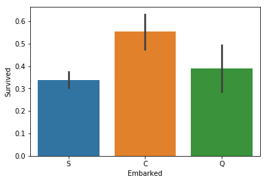

```python
sns.barplot(x='Embarked',y='Survived',data=eda)
```

|  | S | C | Q |
| --- | --- | --- | --- |
| s | 217 | 93 | 30 |
| d | 427 | 75 | 47 |

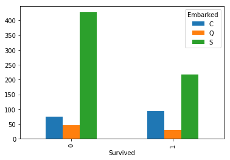

```python
pd.crosstab(eda['Survived'],eda['Embarked']).plot(kind='bar')
s=eda[eda['Survived']==1]['Embarked'].value_counts()
d=eda[eda['Survived']==0]['Embarked'].value_counts()
pd.DataFrame([s,d],index=['s','d'])
```

#### those who embarked from C has more survival rate

### sibsp:

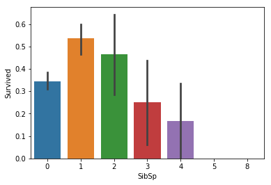

```python
#survived,sibsp,parch,pclass
sns.barplot(x='SibSp',y='Survived',data=eda)
```

|  | 0 | 1 | 2 | 3 | 4 | 5 | 8 |
| --- | --- | --- | --- | --- | --- | --- | --- |
| s | 210.0 | 112.0 | 13.0 | 4.0 | 3.0 | NaN | NaN |
| d | 398.0 | 97.0 | 15.0 | 12.0 | 15.0 | 5.0 | 7.0 |

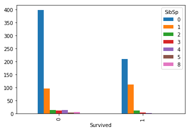

```python
pd.crosstab(eda['Survived'],eda['SibSp']).plot(kind='bar')
s=eda[eda['Survived']==1]['SibSp'].value_counts()
d=eda[eda['Survived']==0]['SibSp'].value_counts()
pd.DataFrame([s,d],index=['s','d'])
```

##### majority of people came single.

### Parch:

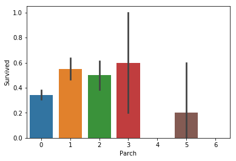

```python
sns.barplot(x='Parch',y='Survived',data=eda)
```

|  | 0 | 1 | 2 | 3 | 4 | 5 | 6 |
| --- | --- | --- | --- | --- | --- | --- | --- |
| s | 233.0 | 65.0 | 40.0 | 3.0 | NaN | 1.0 | NaN |
| d | 445.0 | 53.0 | 40.0 | 2.0 | 4.0 | 4.0 | 1.0 |

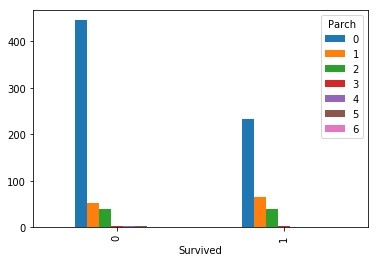

```python
pd.crosstab(eda['Survived'],eda['Parch']).plot(kind='bar')
s=eda[eda['Survived']==1]['Parch'].value_counts()
d=eda[eda['Survived']==0]['Parch'].value_counts()
pd.DataFrame([s,d],index=['s','d'])
```

### P class:

|  | 1 | 2 | 3 |
| --- | --- | --- | --- |
| s | 136 | 87 | 119 |
| d | 80 | 97 | 372 |

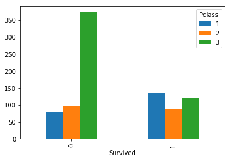

```python
pd.crosstab(eda['Survived'],eda['Pclass']).plot(kind='bar')
s=eda[eda['Survived']==1]['Pclass'].value_counts()
d=eda[eda['Survived']==0]['Pclass'].value_counts()
pd.DataFrame([s,d],index=['s','d'])
```

### continuous&continuous:

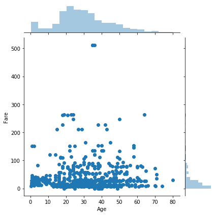

```python
#CATEGORICAL:sex,embarked,,cabin
#CONTINUOUS:AGE,FARE
#DISCREETE:survived,sibsp,parch,pclass

sns.jointplot(x='Age', y='Fare', data = eda)
```

### we will plot heatmap to find correlation among different features

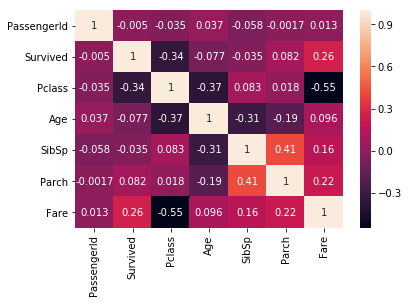

```python
sns.heatmap(eda.corr() ,annot=True)
```

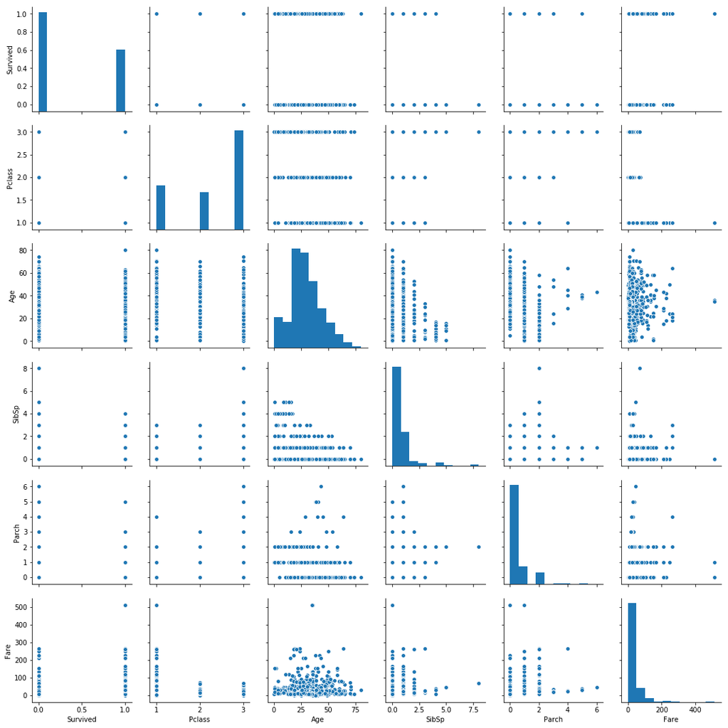

```python
eda_n=eda.iloc[:,1:-2]
sns.pairplot(eda_n)
```

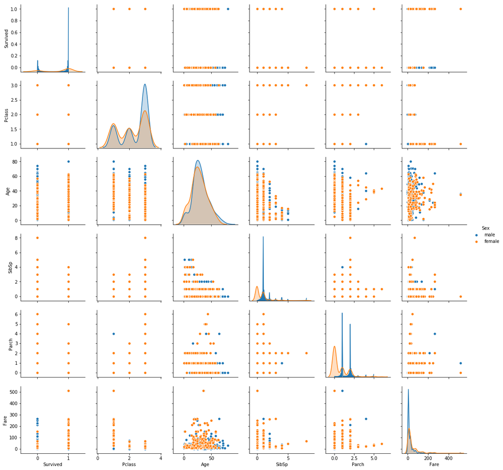

```python
sns.pairplot(eda_n,hue='Sex')
```

### categorical&catgorical:

```
Sex     Embarked
female  C            73
        Q            36
        S           203
male    C            95
        Q            41
        S           441
dtype: int64
```

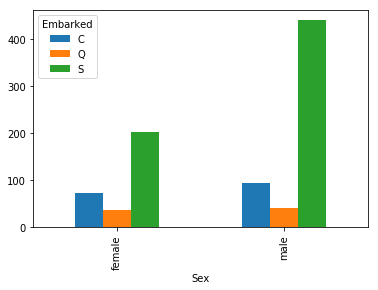

```python
tot= eda.groupby(['Sex', 'Embarked'], axis= 0)
print(tot.size())
pd.crosstab(eda['Sex'],eda['Embarked']).plot(kind='bar')
```

###### more people have embarked from S and list from Q

# STEP4:

```python
eda.isnull().sum()
```

```
PassengerId      0
Survived         0
Pclass           0
Name             0
Sex              0
Age            177
SibSp            0
Parch            0
Ticket           0
Fare             0
Cabin          687
Embarked         2
dtype: int64
```

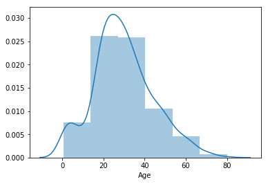

```python
sns.distplot(eda['Age'],bins=6)
```

#### age plot is very closer to normal distribution so we can replace the null values with the mean of age

```python
eda['Age']=eda['Age'].fillna(value=eda['Age'].mean())
eda.isnull().sum()
```

```
PassengerId      0
Survived         0
Pclass           0
Name             0
Sex              0
Age              0
SibSp            0
Parch            0
Ticket           0
Fare             0
Cabin          687
Embarked         2
dtype: int64
```

```python
eda.dropna(axis=1,thresh=686,inplace=True)
eda.isnull().sum()
```

```
PassengerId    0
Survived       0
Pclass         0
Name           0
Sex            0
Age            0
SibSp          0
Parch          0
Ticket         0
Fare           0
Embarked       2
dtype: int64
```

```python
eda['Embarked'].fillna(value=eda['Embarked'].mode()[0],inplace=True)
eda.isnull().sum()
```

```
PassengerId    0
Survived       0
Pclass         0
Name           0
Sex            0
Age            0
SibSp          0
Parch          0
Ticket         0
Fare           0
Embarked       0
dtype: int64
```

###### 1) we have replaced the null values in ages by the mean of the ages.

###### 2)since column Cabin has 75% null values so we dropped the that column

###### 3)for embarked majority of people embarked from S so we filled null values with mode of that column

# STEP5:

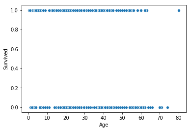

```python
sns.scatterplot(x='Age',y='Survived',data=eda)
```

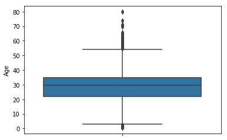

```python
sns.boxplot(y='Age',data=eda)
```

##### Initially there were 66 outliers in age and it seemes to be natural outliers and we need to treat them separately.

```python
feature('Age')
handle('Age')
```

```
0
```

```python
#upper limit=Q3 + 1.5IQR;
#lower limit=Q1-1.5IQR ;

def feature(x):
    iqr = eda[x].quantile(0.75)-eda[x].quantile(0.25)
    ulimit= eda[x].quantile(0.75) + 1.5*iqr
    llimit = eda[x].quantile(0.25) - 1.5*iqr
    outlier = eda[(eda[x]>=ulimit) | (eda[x]<=llimit)]
    c=outlier[x].count()
    y=pd.DataFrame([iqr,ulimit,llimit,c],index=['iqr','ulimit','llimit','outliercount'])
    return y
def handle(x):
    iqr = eda[x].quantile(0.75)-eda[x].quantile(0.25)
    ulimit= eda[x].quantile(0.75) + 1.5*iqr
    llimit = eda[x].quantile(0.25) - 1.5*iqr
    eda.loc[eda[x]>=ulimit,x]=eda[x].quantile(0.95)
    eda.loc[eda[x]<=llimit,x]=eda[x].quantile(0.05)
    return 0
```

```python
handle('Age')
feature('Age')
```

|  | 0 |
| --- | --- |
| iqr | 13.0 |
| ulimit | 54.5 |
| llimit | 2.5 |
| outliercount | 0.0 |

```python
eda['Age'].describe()
```

```
count    891.000000
mean      29.447524
std       11.814011
min        3.000000
25%       22.000000
50%       29.699118
75%       35.000000
max       54.000000
Name: Age, dtype: float64
```

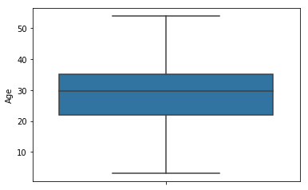

```python
sns.boxplot(y='Age',data=eda)
```

##### the above plot shows outliers has been capped by replacing with 95&5 percentile

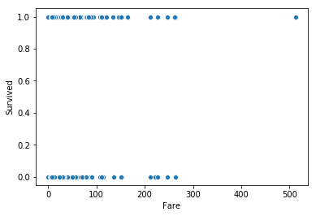

```python
sns.scatterplot(x='Fare',y='Survived',data=eda)
```

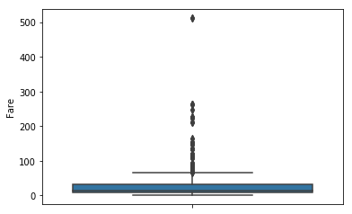

```python
sns.boxplot(y='Fare',data=eda)
```

```python
feature('Fare')
```

|  | 0 |
| --- | --- |
| iqr | 23.0896 |
| ulimit | 65.6344 |
| llimit | -26.7240 |
| outliercount | 116.0000 |

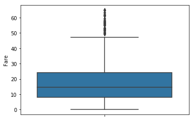

```python
eda.loc[eda['Fare']>=65.6344,'Fare']=eda['Fare'].median()
sns.boxplot(y='Fare',data=eda)
```

```python
eda['Fare'].describe()
```

```
count    891.000000
mean      17.383622
std       12.713016
min        0.000000
25%        7.910400
50%       14.454200
75%       24.150000
max       65.000000
Name: Fare, dtype: float64
```

```python
def featurefare(x):
    iqr = eda[x].quantile(0.75)-eda[x].quantile(0.25)
    ulimit= eda[x].quantile(0.75) + 1.5*iqr
    outlier = eda[(eda[x]>=ulimit)]
    c=outlier[x].count()
    y=pd.DataFrame([iqr,ulimit,c],index=['iqr','ulimit','outliercount'])
    return y
def handlefare(x):
    iqr = eda[x].quantile(0.75)-eda[x].quantile(0.25)
    ulimit= eda[x].quantile(0.75) + 1.5*iqr
    eda.loc[eda[x]>=ulimit,x]=eda[x].quantile(0.85)
    return 0
featurefare('Fare')
handlefare('Fare')
featurefare('Fare')
```

|  | 0 |
| --- | --- |
| iqr | 16.2396 |
| ulimit | 48.5094 |
| outliercount | 0.0000 |

```
count    891.000000
mean      15.969378
std        9.441338
min        0.000000
25%        7.910400
50%       14.454200
75%       24.150000
max       47.100000
Name: Fare, dtype: float64
```

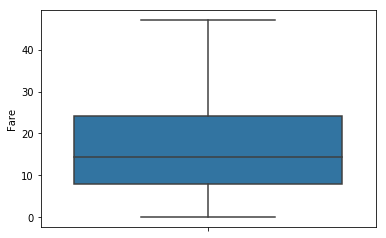

```python
sns.boxplot(y='Fare',data=eda)
eda['Fare'].describe()
```

###### we have now treated outliers by first replacing outliers with median values and then again outliers are treated with 85 percentile

# STEP6:

```python
 cat = eda.dtypes == np.object
print(cat)
```

```
PassengerId    False
Survived       False
Pclass         False
Name            True
Sex             True
Age            False
SibSp          False
Parch          False
Ticket          True
Fare           False
Embarked        True
dtype: bool
```

```python
del(eda['Name'])
del(eda['Ticket'])
cat = eda.dtypes == np.object
print(cat)
```

```
PassengerId    False
Survived       False
Pclass         False
Sex             True
Age            False
SibSp          False
Parch          False
Fare           False
Embarked        True
dtype: bool
```

#### Removed the variables like name and ticket number which does not decide wheather the person survived or not

##### below shows creating dummy variables for catogorical variables like sex and embarked for that first we create dummy data frame with null values and fill it

```python
eda.columns[cat]
```

```
Index(['Sex', 'Embarked'], dtype='object')
```

```python
dummydf = pd.DataFrame()
for i in eda.columns[cat]:
    dummy=pd.get_dummies(eda[i], drop_first=True)
    dummydf=pd.concat([dummydf, dummy], axis=1)
print(dummydf)
```

```
     male  Q  S
0       1  0  1
1       0  0  0
2       0  0  1
3       0  0  1
4       1  0  1
5       1  1  0
6       1  0  1
7       1  0  1
8       0  0  1
9       0  0  0
10      0  0  1
11      0  0  1
12      1  0  1
13      1  0  1
```

[output cut: 49 more lines]

#### Now concating both orignal data frame with dummy data frame to compare

```python
eda_new=pd.concat([eda,dummydf], axis=1)
eda_new
```

|  | PassengerId | Survived | Pclass | Sex | Age | SibSp | Parch | Fare | Embarked | male | Q | S |
| --- | --- | --- | --- | --- | --- | --- | --- | --- | --- | --- | --- | --- |
| 0 | 1 | 0 | 3 | male | 22.000000 | 1 | 0 | 7.25000 | S | 1 | 0 | 1 |
| 1 | 2 | 1 | 1 | female | 38.000000 | 1 | 0 | 14.45420 | C | 0 | 0 | 0 |
| 2 | 3 | 1 | 3 | female | 26.000000 | 0 | 0 | 7.92500 | S | 0 | 0 | 1 |
| 3 | 4 | 1 | 1 | female | 35.000000 | 1 | 0 | 28.85625 | S | 0 | 0 | 1 |
| 4 | 5 | 0 | 3 | male | 35.000000 | 0 | 0 | 8.05000 | S | 1 | 0 | 1 |
| 5 | 6 | 0 | 3 | male | 29.699118 | 0 | 0 | 8.45830 | Q | 1 | 1 | 0 |
| 6 | 7 | 0 | 1 | male | 54.000000 | 0 | 0 | 28.85625 | S | 1 | 0 | 1 |
| 7 | 8 | 0 | 3 | male | 6.000000 | 3 | 1 | 21.07500 | S | 1 | 0 | 1 |
| 8 | 9 | 1 | 3 | female | 27.000000 | 0 | 2 | 11.13330 | S | 0 | 0 | 1 |
| 9 | 10 | 1 | 2 | female | 14.000000 | 1 | 0 | 30.07080 | C | 0 | 0 | 0 |
| 10 | 11 | 1 | 3 | female | 4.000000 | 1 | 1 | 16.70000 | S | 0 | 0 | 1 |
| 11 | 12 | 1 | 1 | female | 54.000000 | 0 | 0 | 26.55000 | S | 0 | 0 | 1 |
| 12 | 13 | 0 | 3 | male | 20.000000 | 0 | 0 | 8.05000 | S | 1 | 0 | 1 |
| 13 | 14 | 0 | 3 | male | 39.000000 | 1 | 5 | 31.27500 | S | 1 | 0 | 1 |
| 14 | 15 | 0 | 3 | female | 14.000000 | 0 | 0 | 7.85420 | S | 0 | 0 | 1 |
| 15 | 16 | 1 | 2 | female | 54.000000 | 0 | 0 | 16.00000 | S | 0 | 0 | 1 |
| 16 | 17 | 0 | 3 | male | 6.000000 | 4 | 1 | 29.12500 | Q | 1 | 1 | 0 |
| 17 | 18 | 1 | 2 | male | 29.699118 | 0 | 0 | 13.00000 | S | 1 | 0 | 1 |
| 18 | 19 | 0 | 3 | female | 31.000000 | 1 | 0 | 18.00000 | S | 0 | 0 | 1 |
| 19 | 20 | 1 | 3 | female | 29.699118 | 0 | 0 | 7.22500 | C | 0 | 0 | 0 |
| 20 | 21 | 0 | 2 | male | 35.000000 | 0 | 0 | 26.00000 | S | 1 | 0 | 1 |
| 21 | 22 | 1 | 2 | male | 34.000000 | 0 | 0 | 13.00000 | S | 1 | 0 | 1 |
| 22 | 23 | 1 | 3 | female | 15.000000 | 0 | 0 | 8.02920 | Q | 0 | 1 | 0 |
| 23 | 24 | 1 | 1 | male | 28.000000 | 0 | 0 | 35.50000 | S | 1 | 0 | 1 |
| 24 | 25 | 0 | 3 | female | 8.000000 | 3 | 1 | 21.07500 | S | 0 | 0 | 1 |
| 25 | 26 | 1 | 3 | female | 38.000000 | 1 | 5 | 31.38750 | S | 0 | 0 | 1 |
| 26 | 27 | 0 | 3 | male | 29.699118 | 0 | 0 | 7.22500 | C | 1 | 0 | 0 |
| 27 | 28 | 0 | 1 | male | 19.000000 | 3 | 2 | 14.45420 | S | 1 | 0 | 1 |
| 28 | 29 | 1 | 3 | female | 29.699118 | 0 | 0 | 7.87920 | Q | 0 | 1 | 0 |
| 29 | 30 | 0 | 3 | male | 29.699118 | 0 | 0 | 7.89580 | S | 1 | 0 | 1 |
| ... | ... | ... | ... | ... | ... | ... | ... | ... | ... | ... | ... | ... |
| 861 | 862 | 0 | 2 | male | 21.000000 | 1 | 0 | 11.50000 | S | 1 | 0 | 1 |
| 862 | 863 | 1 | 1 | female | 48.000000 | 0 | 0 | 25.92920 | S | 0 | 0 | 1 |
| 863 | 864 | 0 | 3 | female | 29.699118 | 8 | 2 | 14.45420 | S | 0 | 0 | 1 |
| 864 | 865 | 0 | 2 | male | 24.000000 | 0 | 0 | 13.00000 | S | 1 | 0 | 1 |
| 865 | 866 | 1 | 2 | female | 42.000000 | 0 | 0 | 13.00000 | S | 0 | 0 | 1 |
| 866 | 867 | 1 | 2 | female | 27.000000 | 1 | 0 | 13.85830 | C | 0 | 0 | 0 |
| 867 | 868 | 0 | 1 | male | 31.000000 | 0 | 0 | 28.85625 | S | 1 | 0 | 1 |
| 868 | 869 | 0 | 3 | male | 29.699118 | 0 | 0 | 9.50000 | S | 1 | 0 | 1 |
| 869 | 870 | 1 | 3 | male | 4.000000 | 1 | 1 | 11.13330 | S | 1 | 0 | 1 |
| 870 | 871 | 0 | 3 | male | 26.000000 | 0 | 0 | 7.89580 | S | 1 | 0 | 1 |
| 871 | 872 | 1 | 1 | female | 47.000000 | 1 | 1 | 28.85625 | S | 0 | 0 | 1 |
| 872 | 873 | 0 | 1 | male | 33.000000 | 0 | 0 | 5.00000 | S | 1 | 0 | 1 |
| 873 | 874 | 0 | 3 | male | 47.000000 | 0 | 0 | 9.00000 | S | 1 | 0 | 1 |
| 874 | 875 | 1 | 2 | female | 28.000000 | 1 | 0 | 24.00000 | C | 0 | 0 | 0 |
| 875 | 876 | 1 | 3 | female | 15.000000 | 0 | 0 | 7.22500 | C | 0 | 0 | 0 |
| 876 | 877 | 0 | 3 | male | 20.000000 | 0 | 0 | 9.84580 | S | 1 | 0 | 1 |
| 877 | 878 | 0 | 3 | male | 19.000000 | 0 | 0 | 7.89580 | S | 1 | 0 | 1 |
| 878 | 879 | 0 | 3 | male | 29.699118 | 0 | 0 | 7.89580 | S | 1 | 0 | 1 |
| 879 | 880 | 1 | 1 | female | 54.000000 | 0 | 1 | 14.45420 | C | 0 | 0 | 0 |
| 880 | 881 | 1 | 2 | female | 25.000000 | 0 | 1 | 26.00000 | S | 0 | 0 | 1 |
| 881 | 882 | 0 | 3 | male | 33.000000 | 0 | 0 | 7.89580 | S | 1 | 0 | 1 |
| 882 | 883 | 0 | 3 | female | 22.000000 | 0 | 0 | 10.51670 | S | 0 | 0 | 1 |
| 883 | 884 | 0 | 2 | male | 28.000000 | 0 | 0 | 10.50000 | S | 1 | 0 | 1 |
| 884 | 885 | 0 | 3 | male | 25.000000 | 0 | 0 | 7.05000 | S | 1 | 0 | 1 |
| 885 | 886 | 0 | 3 | female | 39.000000 | 0 | 5 | 29.12500 | Q | 0 | 1 | 0 |
| 886 | 887 | 0 | 2 | male | 27.000000 | 0 | 0 | 13.00000 | S | 1 | 0 | 1 |
| 887 | 888 | 1 | 1 | female | 19.000000 | 0 | 0 | 30.00000 | S | 0 | 0 | 1 |
| 888 | 889 | 0 | 3 | female | 29.699118 | 1 | 2 | 23.45000 | S | 0 | 0 | 1 |
| 889 | 890 | 1 | 1 | male | 26.000000 | 0 | 0 | 30.00000 | C | 1 | 0 | 0 |
| 890 | 891 | 0 | 3 | male | 32.000000 | 0 | 0 | 7.75000 | Q | 1 | 1 | 0 |

891 rows × 12 columns

##### now we drop the orignal variables and since we have converted orignal into dummy variables

```python
eda_new.drop(['Sex','Embarked'], axis=1, inplace=True)
```

[output not shown]

```python
eda_new
```

|  | PassengerId | Survived | Pclass | Age | SibSp | Parch | Fare | male | Q | S |
| --- | --- | --- | --- | --- | --- | --- | --- | --- | --- | --- |
| 0 | 1 | 0 | 3 | 22.000000 | 1 | 0 | 7.25000 | 1 | 0 | 1 |
| 1 | 2 | 1 | 1 | 38.000000 | 1 | 0 | 14.45420 | 0 | 0 | 0 |
| 2 | 3 | 1 | 3 | 26.000000 | 0 | 0 | 7.92500 | 0 | 0 | 1 |
| 3 | 4 | 1 | 1 | 35.000000 | 1 | 0 | 28.85625 | 0 | 0 | 1 |
| 4 | 5 | 0 | 3 | 35.000000 | 0 | 0 | 8.05000 | 1 | 0 | 1 |
| 5 | 6 | 0 | 3 | 29.699118 | 0 | 0 | 8.45830 | 1 | 1 | 0 |
| 6 | 7 | 0 | 1 | 54.000000 | 0 | 0 | 28.85625 | 1 | 0 | 1 |
| 7 | 8 | 0 | 3 | 6.000000 | 3 | 1 | 21.07500 | 1 | 0 | 1 |
| 8 | 9 | 1 | 3 | 27.000000 | 0 | 2 | 11.13330 | 0 | 0 | 1 |
| 9 | 10 | 1 | 2 | 14.000000 | 1 | 0 | 30.07080 | 0 | 0 | 0 |
| 10 | 11 | 1 | 3 | 4.000000 | 1 | 1 | 16.70000 | 0 | 0 | 1 |
| 11 | 12 | 1 | 1 | 54.000000 | 0 | 0 | 26.55000 | 0 | 0 | 1 |
| 12 | 13 | 0 | 3 | 20.000000 | 0 | 0 | 8.05000 | 1 | 0 | 1 |
| 13 | 14 | 0 | 3 | 39.000000 | 1 | 5 | 31.27500 | 1 | 0 | 1 |
| 14 | 15 | 0 | 3 | 14.000000 | 0 | 0 | 7.85420 | 0 | 0 | 1 |
| 15 | 16 | 1 | 2 | 54.000000 | 0 | 0 | 16.00000 | 0 | 0 | 1 |
| 16 | 17 | 0 | 3 | 6.000000 | 4 | 1 | 29.12500 | 1 | 1 | 0 |
| 17 | 18 | 1 | 2 | 29.699118 | 0 | 0 | 13.00000 | 1 | 0 | 1 |
| 18 | 19 | 0 | 3 | 31.000000 | 1 | 0 | 18.00000 | 0 | 0 | 1 |
| 19 | 20 | 1 | 3 | 29.699118 | 0 | 0 | 7.22500 | 0 | 0 | 0 |
| 20 | 21 | 0 | 2 | 35.000000 | 0 | 0 | 26.00000 | 1 | 0 | 1 |
| 21 | 22 | 1 | 2 | 34.000000 | 0 | 0 | 13.00000 | 1 | 0 | 1 |
| 22 | 23 | 1 | 3 | 15.000000 | 0 | 0 | 8.02920 | 0 | 1 | 0 |
| 23 | 24 | 1 | 1 | 28.000000 | 0 | 0 | 35.50000 | 1 | 0 | 1 |
| 24 | 25 | 0 | 3 | 8.000000 | 3 | 1 | 21.07500 | 0 | 0 | 1 |
| 25 | 26 | 1 | 3 | 38.000000 | 1 | 5 | 31.38750 | 0 | 0 | 1 |
| 26 | 27 | 0 | 3 | 29.699118 | 0 | 0 | 7.22500 | 1 | 0 | 0 |
| 27 | 28 | 0 | 1 | 19.000000 | 3 | 2 | 14.45420 | 1 | 0 | 1 |
| 28 | 29 | 1 | 3 | 29.699118 | 0 | 0 | 7.87920 | 0 | 1 | 0 |
| 29 | 30 | 0 | 3 | 29.699118 | 0 | 0 | 7.89580 | 1 | 0 | 1 |
| ... | ... | ... | ... | ... | ... | ... | ... | ... | ... | ... |
| 861 | 862 | 0 | 2 | 21.000000 | 1 | 0 | 11.50000 | 1 | 0 | 1 |
| 862 | 863 | 1 | 1 | 48.000000 | 0 | 0 | 25.92920 | 0 | 0 | 1 |
| 863 | 864 | 0 | 3 | 29.699118 | 8 | 2 | 14.45420 | 0 | 0 | 1 |
| 864 | 865 | 0 | 2 | 24.000000 | 0 | 0 | 13.00000 | 1 | 0 | 1 |
| 865 | 866 | 1 | 2 | 42.000000 | 0 | 0 | 13.00000 | 0 | 0 | 1 |
| 866 | 867 | 1 | 2 | 27.000000 | 1 | 0 | 13.85830 | 0 | 0 | 0 |
| 867 | 868 | 0 | 1 | 31.000000 | 0 | 0 | 28.85625 | 1 | 0 | 1 |
| 868 | 869 | 0 | 3 | 29.699118 | 0 | 0 | 9.50000 | 1 | 0 | 1 |
| 869 | 870 | 1 | 3 | 4.000000 | 1 | 1 | 11.13330 | 1 | 0 | 1 |
| 870 | 871 | 0 | 3 | 26.000000 | 0 | 0 | 7.89580 | 1 | 0 | 1 |
| 871 | 872 | 1 | 1 | 47.000000 | 1 | 1 | 28.85625 | 0 | 0 | 1 |
| 872 | 873 | 0 | 1 | 33.000000 | 0 | 0 | 5.00000 | 1 | 0 | 1 |
| 873 | 874 | 0 | 3 | 47.000000 | 0 | 0 | 9.00000 | 1 | 0 | 1 |
| 874 | 875 | 1 | 2 | 28.000000 | 1 | 0 | 24.00000 | 0 | 0 | 0 |
| 875 | 876 | 1 | 3 | 15.000000 | 0 | 0 | 7.22500 | 0 | 0 | 0 |
| 876 | 877 | 0 | 3 | 20.000000 | 0 | 0 | 9.84580 | 1 | 0 | 1 |
| 877 | 878 | 0 | 3 | 19.000000 | 0 | 0 | 7.89580 | 1 | 0 | 1 |
| 878 | 879 | 0 | 3 | 29.699118 | 0 | 0 | 7.89580 | 1 | 0 | 1 |
| 879 | 880 | 1 | 1 | 54.000000 | 0 | 1 | 14.45420 | 0 | 0 | 0 |
| 880 | 881 | 1 | 2 | 25.000000 | 0 | 1 | 26.00000 | 0 | 0 | 1 |
| 881 | 882 | 0 | 3 | 33.000000 | 0 | 0 | 7.89580 | 1 | 0 | 1 |
| 882 | 883 | 0 | 3 | 22.000000 | 0 | 0 | 10.51670 | 0 | 0 | 1 |
| 883 | 884 | 0 | 2 | 28.000000 | 0 | 0 | 10.50000 | 1 | 0 | 1 |
| 884 | 885 | 0 | 3 | 25.000000 | 0 | 0 | 7.05000 | 1 | 0 | 1 |
| 885 | 886 | 0 | 3 | 39.000000 | 0 | 5 | 29.12500 | 0 | 1 | 0 |
| 886 | 887 | 0 | 2 | 27.000000 | 0 | 0 | 13.00000 | 1 | 0 | 1 |
| 887 | 888 | 1 | 1 | 19.000000 | 0 | 0 | 30.00000 | 0 | 0 | 1 |
| 888 | 889 | 0 | 3 | 29.699118 | 1 | 2 | 23.45000 | 0 | 0 | 1 |
| 889 | 890 | 1 | 1 | 26.000000 | 0 | 0 | 30.00000 | 1 | 0 | 0 |
| 890 | 891 | 0 | 3 | 32.000000 | 0 | 0 | 7.75000 | 1 | 1 | 0 |

891 rows × 10 columns